# Cholera Geo4Health Thesis

0.0.0.9000

Yemen Outbreak anlysis

Andrea Pedot (Unit of Biostatistics, Epidemiology, and Public Health)https://www.unipd-ubep.it/ , Corrado Lanera https://CorradoLanera.it (Unit of Biostatistics, Epidemiology, and Public Health)https://www.unipd-ubep.it/  
2024-09-22

[figure not shown]

```r
htmltools::img(
 src = knitr::image_uri(here("man", "img", "LAIMS.png")),
 alt = 'logo',
 style = 'position:absolute; top:0; right:0; padding:10px;'
 )
```

## Introduction

The project focuses on the geospatial analysis of a cholera outbreak in Yemen between 2017 and 2018, using various techniques that leverage the spatial dimension of data.

### Cholera epidemiology and risk factors

Cholera is a worldwide problem. It is a highly virulent disease that spreads through the contamination of food and water [@azman_incubation]. The World Health Organization considers it a global threat to public health and an indicator of inequity and lack of social development (“Cholera” n.d.). The typical presentation is a patient with severe acute watery diarrhoea, with severe cases that can cause severe dehydration or even death if left untreated.

Unfortunately, accessing supportive care can be complicated, even if it proves cheap and effective. Most patients can be treated successfully through the Oral Rehydration Solution (ORS), up to 6 litres on the first day. Those interventions should be available at the community level (Oral Rehydration Points, or ORP). If the patient is at risk of shock, intravenous fluids and antibiotics are required, usually in Cholera Treatment Units (CTUs) or Centers (CTCs). For under-5 children, Zync is an effective supplement to add to ORS therapy. **The Case Fatality Rate (CFR) should remain under 1% when treatment is provided early.**

The disease is caused by *Vibrio cholerae*, a bacteria that began spreading during the 19th century from its original reservoir in the Ganges delta in India. Most people infected don’t develop any symptoms (but are nevertheless contagious and will shed the bacteria through their faeces for 1-10 days after infection). Most of those who develop symptoms have mild to moderate ones, usually between 12 hours and five days. A minority of patients will develop the severe form, which is threatening patient survival (“Cholera” n.d.).

Out of the many serogroups of V. cholerae, only O1 and O139 have an outbreak potential. O1 itself caused all the recent outbreaks, but there is no way to distinguish it from the clinical symptoms shown by the patients.

Cholera transmission is closely linked to the lack of Water Access, Sanitation, and Hygiene services, particularly restrooms and other facilities. Particularly at high risk are peri-urban areas with precarious conditions (slums), overcrowded Internally Displaced People camps, or remote areas where the population relies on unprotected water sources (“Cholera” n.d.). Without proper sanitation and waste management systems, water sources can become further contaminated, and the water scarcity problem is even worse during drought or flooding (Ng et al. 2020).

The world is currently experiencing the 7th pandemic, which started in South Asia in 1961, reached Africa in 1971, and the Americas in 1991. It is now considered endemic in many countries. WHO continues to report a high number of cases, with 44 countries reporting them in 2022, for a total of nearly 0.5 million cases worldwide and more than 2,300 deaths.

A series of interventions is required to control Cholera and reduce deaths, combining early warning and surveillance systems and strengthening health and WASH systems (“Cholera” n.d.). The Red Cross Movement adopts a three-pronged approach:

- **Break the transmission chain** through community mobilisation and volunteer engagement in Branch Outbreak Response Teams. The interventions incorporate local culture, practices, and beliefs to promote good hygiene practices and prevent contamination or re-contamination.
- **Lower mortality** through Oral Rehydration Solution distribution in established points (ORPs) or outposts. This is critical, as the local health system may be unable to develop the required number of ORPs.
- **Oral Cholera Vaccination (OCV) campaigns**, whenever those are available through the Global OCV stockpile supported by Gavi, the Vaccine Alliance

The appropriate timing of those interventions and the geographical area where they need to be implemented are crucial factors in Outbreak Control (“Cholera IFRC” 2024). On the other hand, long-term solutions entail developing the WASH infrastructure and improving socio-economic conditions (“Cholera” n.d.).

Surveillance is an integrated system that ensures prompt detection of suspected cholera cases, followed by information sharing with other health system levels, up to international notification according to the International Health Regulations (IHR). The suspect is based on clinical suspicion (acute watery diarrhoea in a patient older than two years, with severe dehydration or death). Rapid diagnostic tests are valuable tools at the healthcare facility level but are not available everywhere. The PCR test is the usual laboratory confirmation carried out by country-level authorities since even a single case is considered an outbreak, as per the IHR, even if the notification is no longer mandatory but follows the criteria specified in Annex 2 (“Public Health Emergencies: Preparedness and Response,” n.d.).

The Global Roadmap to Ending Cholera (“Ending Cholera - A Global Roadmap to 2030 - World ReliefWeb” 2017) is an initiative of the Global Taskforce on Cholera Control that focuses on three strategic axes:

1. Early detection and quick response to contain outbreaks
2. A targeted multi-sectoral approach to prevent cholera recurrence, focusing on cholera hotspots, which are relatively small areas that are the most chronically affected by cholera cases
3. An effective mechanism of coordination for technical support, advocacy, resource mobilisation, and partnership at local and global levels

This thesis project focuses on the First Strategic Pillar and aims to prove the feasibility of Anticipatory Approaches to cholera outbreaks.

### Cholera burden globally

Unfortunately, the global burden of Cholera is unknown mainly because the majority of cases are not reported. The low reporting can be attributed to the limited capacity of epidemiological surveillance and laboratories and social, political, and economic disincentives for reporting.

Approximately 1.3 billion people are at risk for Cholera in endemic countries. An estimated 2.86 million cholera cases (uncertainty range: 1.3m-4.0m) occur annually in endemic countries. Among these cases, there are an estimated 95,000 deaths (uncertainty range: 21,000-143,000) (Ali et al. 2015).

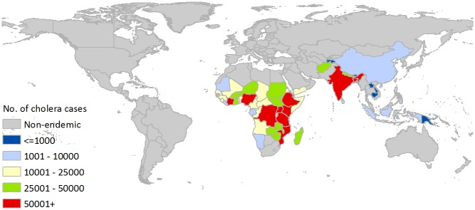

### Cholera Burden in Yemen

According to the World Bank, Yemen is a lower-middle-income country with a population of more than 26 million. However, due to ongoing conflicts, its population health indicators are some of the lowest in the world (“World Bank Open Data” n.d.).

Yemen is considered a country where Cholera is endemic, given that cases are routinely observed. The Global burden of disease estimates 10.7 million people at risk, with an incidence rate (1000) of 1.64 and more than 17500 cases annually, a Case Fatality Rate of 3.2, and 561 deaths annually (Ali et al. 2015). Cumulatively, between 2016 and 2021, more than 2.5 million cases were reported, including 4000 deaths (“Yemen – Cholera Outbreak (DG ECHO, DG ECHO Partners) (ECHO Daily Flash of 4 December 2023) - Yemen ReliefWeb” 2023).

The current analysis focuses on the 2017-2018 outbreak, but even at the end of 2023, cholera cases surged in six governorates in Yemen. According to the DG ECHO, 80% of cases were among migrants (“Yemen – Cholera Outbreak (DG ECHO, DG ECHO Partners) (ECHO Daily Flash of 4 December 2023) - Yemen ReliefWeb” 2023). Nonetheless, the Ministry of Public Health and Population in Aden declared the official outbreak at the national level only later. In March, there was an increase again in the northern governorates with over 6000 suspected cholera cases, 56 deaths (case fatality rate of 0.9%), and 47% of cases being clinically severe (“UNICEF Yemen Humanitarian Situation Report No. 1 - January to March 2024 [EN/AR] - Yemen ReliefWeb” 2024). In June 2024, the International Organisation on Migration (IOM) raised concerns over 30,000 suspected cases, potentially reaching 255,000 by September 2024 if preparedness and response activities are not scaled up (“Acute Diarrhea and Cholera Outbreak in Yemen Exacerbated by Decade of Conflict – IOM Warns” n.d.).

Yemen experienced the most significant reported cholera outbreak in recent history, from 2016 to 2022. The analysis focuses on a short period for which epidemiological data are available. The main driver has been a protracted civil war, which damaged the already vulnerable health and WASH infrastructure. Chronic malnutrition, cyclical floods, and drought episodes have compounded this(Ng et al. 2020).

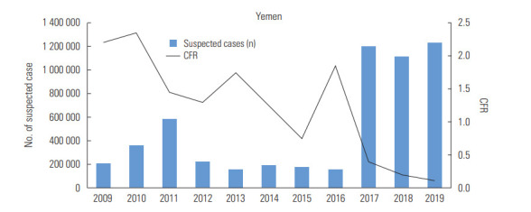

The situation worsened in late 2016, as seen from the Chart. This resulted in more than 16 million people without essential services and more than 2 million IDPs being forced to live in deprived and harsh environments. This contributed to a sustained number of cases, probably due to groundwater contamination and a general lack of safe drinking water in the country (Ng et al. 2020). A national electronic Disease Early Warning System (eDEWS) was established in 2016 and used together with the Bulletin of the Yemen Ministry of Health to monitor the evolution of the outbreak, providing a reliable source of data even if not always timely due to the ongoing conflict (Dureab et al. 2019).

Increased rainfall, flooding, and a powerful El Niño and winds may have further contaminated water sources in Yemen and aided the spread of cholera-contaminated flying insects (chironomids) from the Horn of Africa to Yemen (Paz 2019).

### Anticipatory Action

The UN Office for the Coordination of Humanitarian Affairs (OCHA) defines Anticipatory Action (AA) as those taken ahead of a disaster to support vulnerable communities. AA emerges from the increasing confidence that we can predict the occurrence and impact of some hazards (“Anticipatory Action OCHA” 2024).

It is composed of three main components:

1. A pre-agreed trigger consists of thresholds and decision-making rules based on reliable, timely, measurable forecasts. The advancement of weather forecasting and climate science enables more actions (“Anticipatory Action – Red Cross Red Crescent Climate Centre” n.d.).
2. **Pre-agreed activities:** This consists of accountable, feasible, effective and efficient actions to be implemented to support vulnerable communities in the window of opportunity between the trigger moment and the full impact of a shock
3. **Pre-arranged financing:** This consists of guaranteed funding available to be released based on the pre-agreed trigger for the pre-agreed activities.

The Red Cross Movement usually adds a fourth component: the capacity to implement those actions on time. This is crucial, and capacity-building efforts are needed to ensure readiness is non-trivial. Depending on the type of hazard and forecasts available, anticipatory action can be carried out well ahead of the shock (for slower onset events) or just before the impacts fully take hold (for more rapid-onset events) (“What Is Anticipatory Action?” n.d.).

The International Federation of Red Cross Red Crescent Societies defines with a broader scope the actions taken to reduce the humanitarian impacts of a forecast hazard before it occurs or before its most acute impacts are felt “Operational Framework for Anticipatory Action 2021-2025 IFRC” (2022). This additional component enables the definition to be extended to epidemics.

The decision to act is based on a forecast, or collective risk analysis, of when, where and how the event will unfold. Anticipatory action is reshaping the humanitarian system, shifting from reacting to hazards to acting ahead of them (“What Is Anticipatory Action?” n.d.).

### Anticipatory Action for Epidemics

Even if there is great attention on Anticipatory Action for Epidemics, only a few viable examples are available. Anticipation Hub recognises that technological progress in scientific modelling and forecasting systems is enabling better predictions of who, how, when, and where people might be affected by disease outbreaks and epidemics (“Health and Anticipatory Action” n.d.).

Health hazards differ from weather-related ones in different ways:

- Risk Analysis and Early Warning systems in the health sector are radically different since forecasting models are of a different nature. Also, it is widespread in the Health sector to base clinical and public health decisions on risk assessment tools instead of hard thresholds. This is done to enable contextual information, difficult to capture in triggers, to be part of the decision process (“Risk Assessment WHO” n.d.)
- The political sensitivity of activation, which makes relying on historical data difficult, given both the delays in reporting and the different capacity of health systems to report
- Early Actions are interlinked with the disaster impact. While for cyclones AA can reduce the impact, for Epidemics, the number of cases itself depends on the Early Actions, thus changing the disaster

In 2021, the World Health Organization (WHO), UNICEF, the International Organization for Migration (IOM), as well as scientists and researchers from the medical, public health, and climate communities are working to test if anticipatory action can stop an outbreak from becoming a crisis in Yemen, Mozambique, and the Democratic Republic of the Congo. The pilot initiative, part of a larger portfolio to scale up anticipatory action, is co-sponsored by the UN Office for the Coordination of Humanitarian Affairs (OCHA), the Global Task Force on Cholera Control (GTFCC), the Risk-Informed Early Action Partnership (REAP), the UK Government, and the Red Cross, and financed by the UN Central Emergency Response Fund (CERF) (“Getting Ahead of Cholera and Putting Cholera Behind” n.d.).

Particularly in the trigger part, it is recognised that triggers can take into consideration different factors:

- Suspected cholera cases before confirmation from the laboratory or reported cases in nearby locations to anticipate preparedness activities and scale up surveillance systems
- Sudden shocks such as floods, drought or large displacement waves.
- A reduction in vaccine coverage or deteriorating water and sanitation conditions.
- Temperature, rainfall, and other predictable environmental factors will provide significant additional lead time and help dynamically target at-risk areas, including where to detect contaminated water.
- …

Those different possibilities have been reduced to three main approaches in the recent “Anticipatory Action for Epidemics” briefing from the Anticipation Hub (Alcayna 2023), with also suggestions on how to develop them:

1. Identify the health impacts of hydrometeorological hazards, including a health component into existing protocols for other hazards, such as floods or cyclones.
2. Multi-stepped composite (surveillance and aggravating factors). This approach combines different indicators, including surveillance data on the disease of interest and known drivers of disease transmission, to establish a composite trigger.
3. Mathematical models predict outbreak risk and the probability of a future outbreak in a given country or location.

That said, developing a protocol for Epidemics requires shifting the mindset from preventing an outbreak to preventing it from reaching critical levels.

## Methods

### Main objective of the analysis

Usually, disease Early Warning systems focus on defining an alert or alarm level for the administrative subdivision where the suspected or confirmed case is found. This analysis aims to explore the geographical and temporal dimensions of a two-year-long Cholera outbreak in Yemen and test the feasibility of an alert for neighbouring areas with different lead times.

### Analysis Plan

Given the complexity of the task, a few assumptions are kept:

- At this stage, no meteorological data is integrated. The model relies only on epidemiological variables in each administrative area.
- The analysis focuses on the first administrative level since data are made freely available only at this level.
- No considerations are made for population movement (e.g., road network or local markets) or displacement dynamics (e.g., within or across the country). Only the geographical proximity of the administrative areas is considered.

Exploration of temporal and geographical dynamics:

Once the preprocessing and exploration are completed, modelling steps can be implemented.

- The target of prediction is the level of a particular district, some weeks in advance, identified in the exploration stage.
- Three models are tested: the first uses the number of cases, the second uses the CFR, and the third uses the districts’ attack rates as input variables. All of them are BYM models with the 3-level classification as a covariate.
- A fourth model, a non-bayesian Poisson model, is also used as a reference.

### Data sources

Data for this project come from two primary sources, both accessible through the Humanitarian Data Exchange portal.

#### Administrative subdivisions of Yemen

The UN Office for Coordination of Humanitarian Affairs provided a group of georeferenced shapefiles at the different administrative levels. For the current project, shapes are collected at the governorate level (adm 1) (“Yemen - Subnational Administrative Boundaries - Humanitarian Data Exchange” n.d.).

Those data are prepared by the Central Statistical Organisation and distributed under a Creative Commons Attribution for Intergovernmental Organisations.

All data can be downloaded from [this website](https://data.humdata.org/dataset/cod-ab-yem). In particular, the “Administrative Divisions Shapefiles.zip” contains the “yem_admbnda_adm1_govyem_cso_20191002.shp,” which has been used for the project once copied into the folder “data-raw.”

#### Yemen Cholera Outbreak Epidemiology Update Data

This dataset provides numbers of suspected cholera cases, deaths, case fatality rates (%) and attack rates (per 1,000) by governorate in the Yemen cholera outbreak since 27 April 2017. The data contains figures from epi bulletins and weekly and daily bulletins. The data are manually extracted from the Yemen cholera outbreak epidemiology updates produced by WHO Yemen. The same license as the previous dataset applies. Unfortunately, after 18 February 2018, governorate level updates were discontinued (“Yemen: Cholera Outbreak Epidemiology Update Data - Humanitarian Data Exchange” n.d.).

All data can be downloaded from [this website](https://data.humdata.org/dataset/yemen-cholera-outbreak-daily-epidemiology-update?), particularly the “Yemen Governorate Level Cholera Epidemiology Data.csv”, which was then used for the project once copied into the folder “data-raw”. Different variables are available, in **bold** the one maintained for subsequent analysis.

- **Date** when the figures were reported
- The **Governorate** name, as reported in the WHO epidemiology bulletin
- Number of **Cases** recorded in the governorate since 27 April 2017
- Number of **Deaths** recorded in the governorate since 27 April 2017
- **CFR** (%), the case fatality rate in the governorate since 27 April 2017
- **Attack Rate** (per 1000), the attack rate per 1,000 of the population
- COD Gov English/COD Gov Arabic/COD Gov Pcode (3 columns). The English/Arabic/PCODE name for the governorate according to the Inter-Agency Standing Committee (IASC) Common Operation Datasets (CODs) for Yemen
- The type of bulletin from which the data was extracted (includes Epidemiology bulletin, Weekly epidemiology bulletin, Daily epidemiology update)
- The URL of the bulletin from which the data was extracted.

### Data preprocessing

The main tools for the whole project have been R Statistical Software (R Core Team 2023) and OpenBugs (Lunn et al. 2009) for the Bayesian modelling. A GitHub repo has been created to facilitate version control and the laims.analysis template has been used. The template incorporates most of the libraries needed to reduce the pipeline creation and maintenance and isolates the whole project as a package. The complete pipeline can be seen in the image below.

```r
targets::tar_visnetwork(targets_only = TRUE,exclude = starts_with("fig"))
```

[output not shown]

[interactive chart not shown]

The above figure shows different preprocessing steps, which are available as part of the package:

- Grouping data from different reports by Epidemiological Week and Governorate so that they can be visualised and analysed on a constant time frame
- Merging the Yemen shapefile with the epidemiological data (cases, deaths, CFR and attack rate), grouped by epidemiological week.
- Calculating the adjacency matrix used for the BYM models.
- Calculate the target variable and the 3-weekly CFR, as well as new cases and attack rate, as per the analytical plan.

## Results and discussion

Results and discussion follow the pipeline outlined above. Data integrity information is checked before the results are presented.

### Data exploration and visualisation - Temporal trends

The four main variables used to track a cholera outbreak are the number of cases, the attack rate, deaths, and the Case Fatality Rate. To get a general picture, the absolute values (since the start of the outbreak) are visualised, both by district and cumulatively.

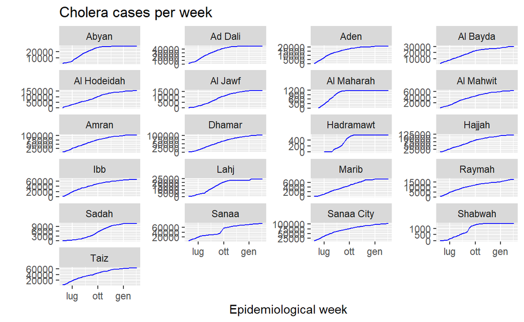

```r
#Fig 1b - same as 1c  but broken down by district
tar_read(fig_1b_1)
```

Different dynamics are shown across the 21 governorates analysed, with some of them (Abyan, Ad Dali, Shabwa, …) showing a stop after the initial increase, while others that never managed to control the outbreaks (Dhamar, Sanaa, both rural and city, Raymah,…).

Another interesting phenomenon is the sudden spikes in the first derivative, as can be observed in Sanaa (rural), Hadramawt, or Shabwah, where the new cases are grouped in a short timeframe that is indicative of an immediate worsening of the situation.

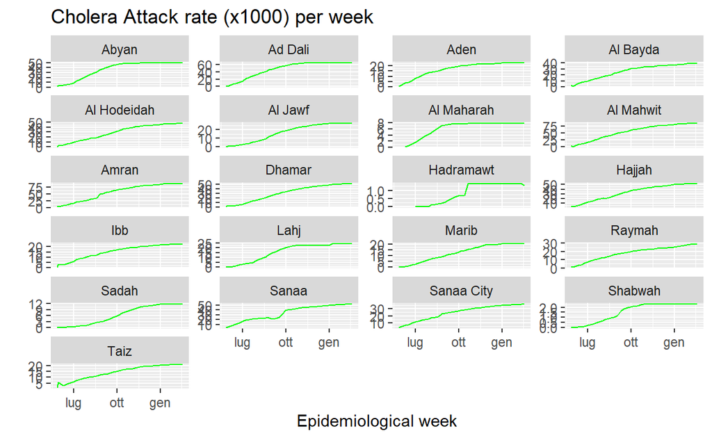

```r
tar_read(fig_1b_2)
```

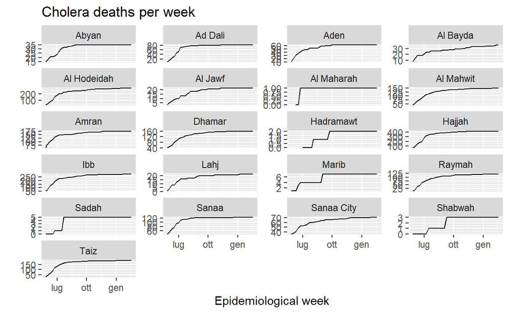

```r
tar_read(fig_1b_3)
```

Deaths are a hard outcome that is usually easy to report at the Health Facility level compared to other indicators. Even in this case, there is significant variability across the regions, from only a few recorded deaths (Sadah, Shabwah) to hundreds of them (Amran, Ibb, Taiz,…). Since cholera does not usually cause permanent disabilities, death is the most important outcome to be monitored, but as for the absolute number of new cases, to understand the implication, a new metric is needed.

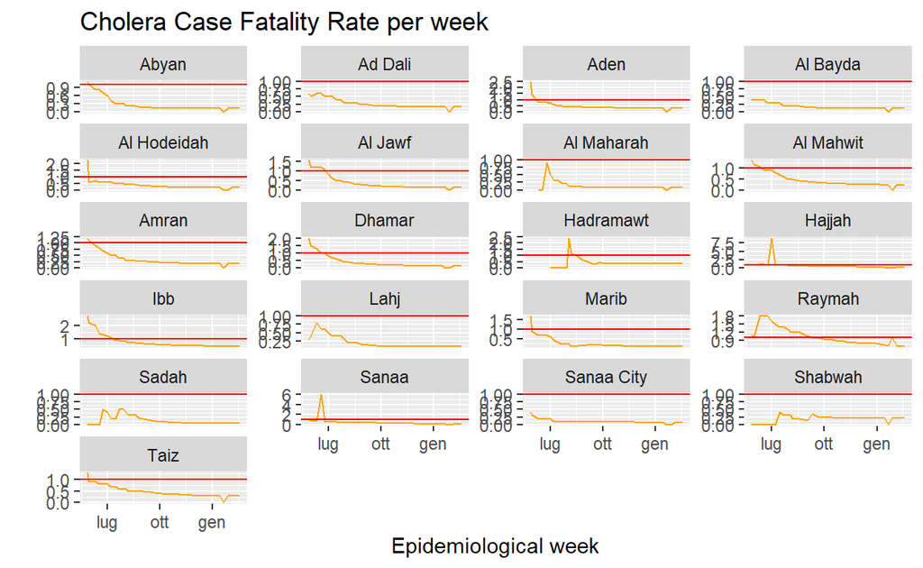

```r
tar_read(fig_1b_4) +
  geom_hline(yintercept = 1, color = "red")
```

Case-Fatality Rate, apart from setting standards for the assistance provided (should be <1%), is also a factor that shows the efficacy of the health system as a whole. The dataset shows the absolute CFR (from the start of the outbreak), so it’s the only variable that is steadily decreasing. This, though, does not provide information on the moment-by-moment evolution of the epidemic.

In addition, it is notable that a spike was seen at the beginning of the outbreak in most of the regions. This is due to a combination of factors: at the beginning, confirmed cases are low and are usually the worst in terms of clinical conditions. Scaling up the health system capacity and risk communication activities are also effective ways to lower overall mortality (and fatality).

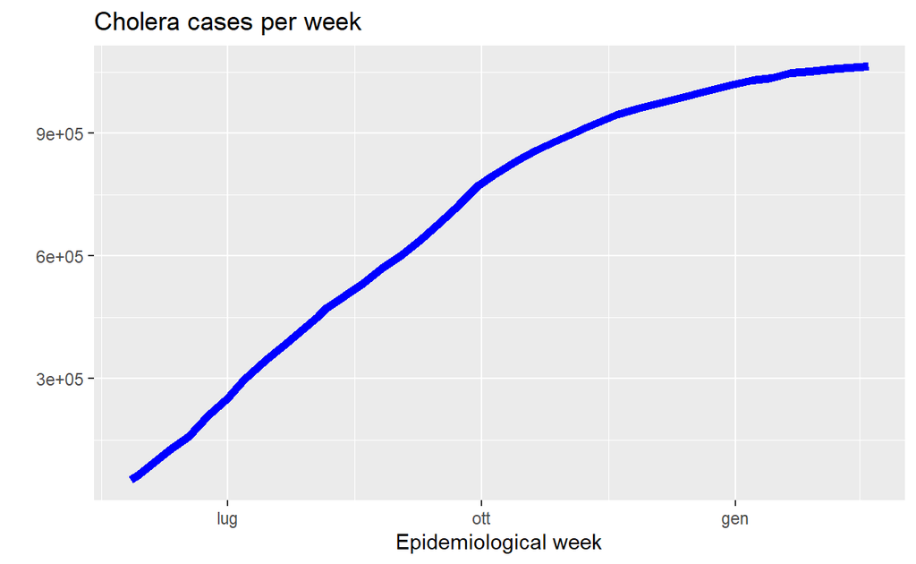

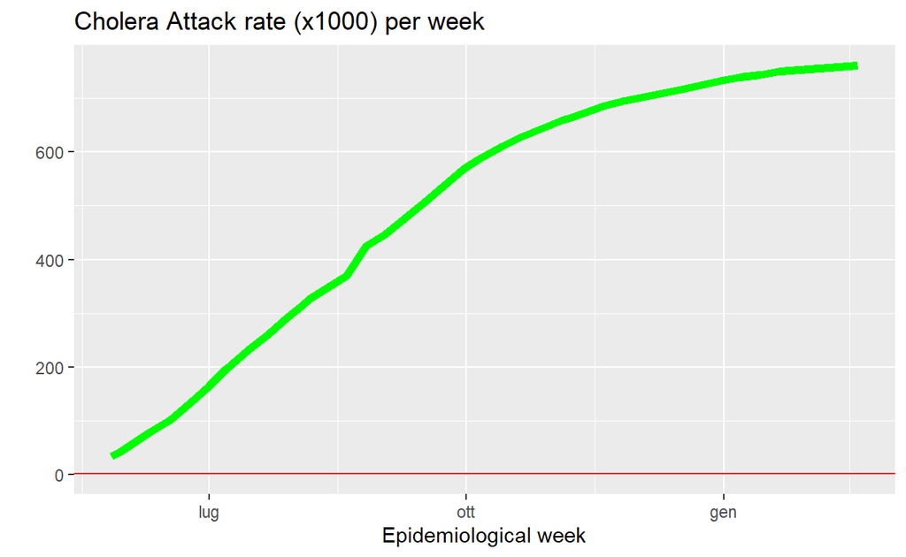

```r
#Fig 1c - whole epidemic curve (4 panels with the four epi variables)
tar_read(fig_1c_1)
tar_read(fig_1c_2) +
  geom_hline(yintercept = 1, color = "red")
```

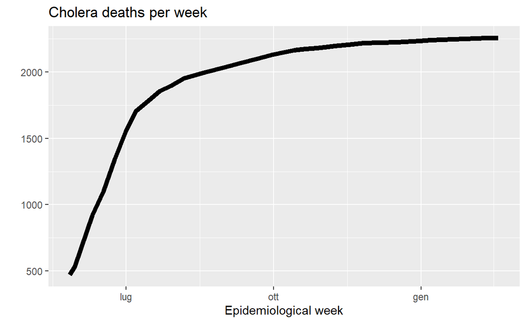

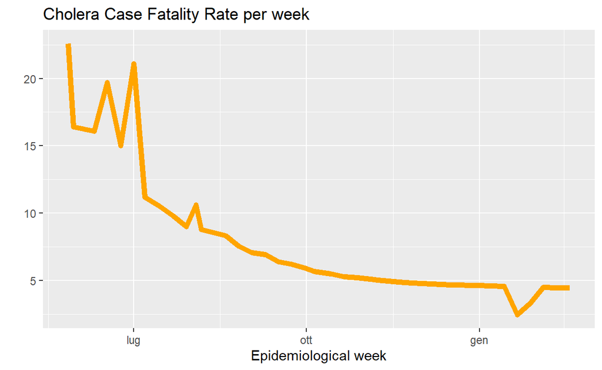

```r
tar_read(fig_1c_3)
tar_read(fig_1c_4)
```

Even though cumulative data are the standard way to collect that information, additional variables have been calculated in the pre-processing to show the cumulative ones only for the previous four weeks. This provides a different picture, more representative of what happened in the previous month for that particular week.

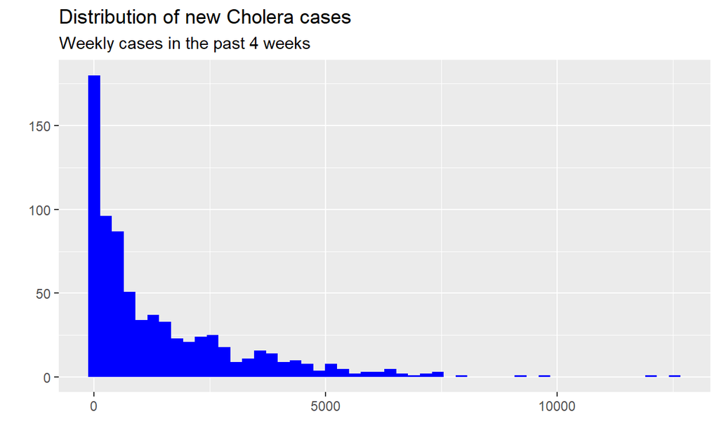

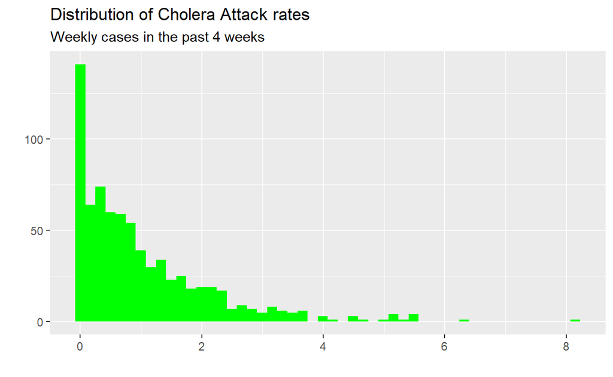

```r
#Fig 1e - distribution of new cases and attack_rate
tar_read(fig_1e_1)
tar_read(fig_1e_2)
```

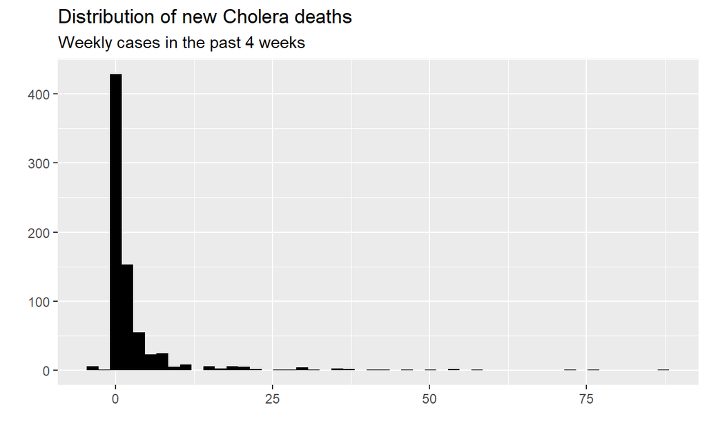

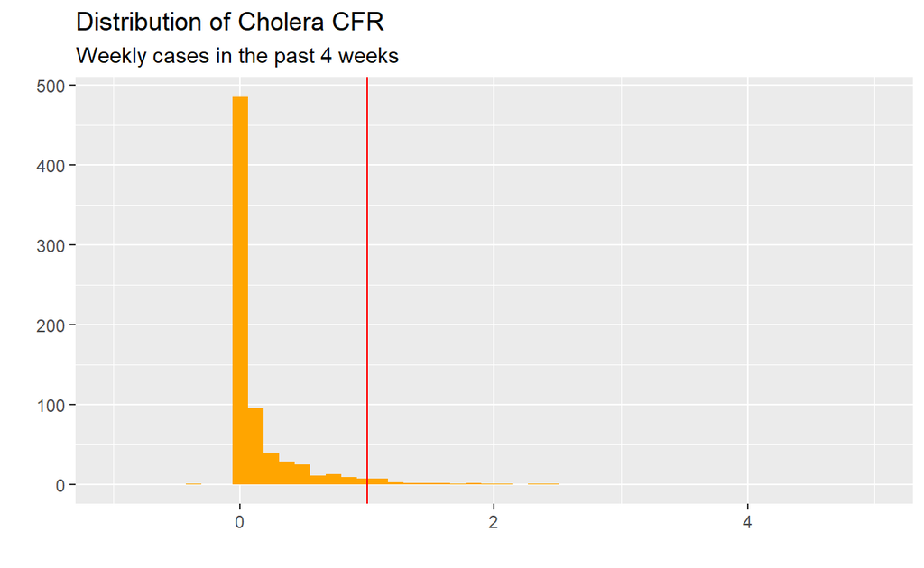

```r
#Fig 1f - distribution of new_deaths and cfr
tar_read(fig_1f_1)
tar_read(fig_1f_2) +
  scale_x_sqrt() +
  xlim(-1,5) +
  geom_vline(xintercept = 1, color = "red")
```

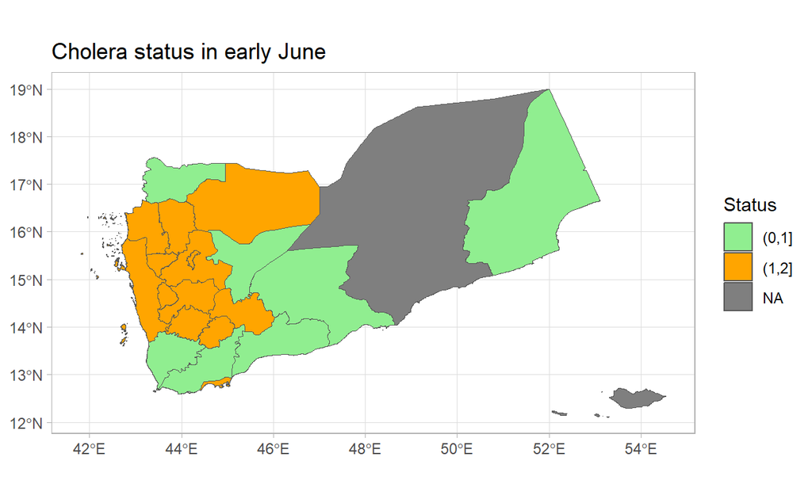

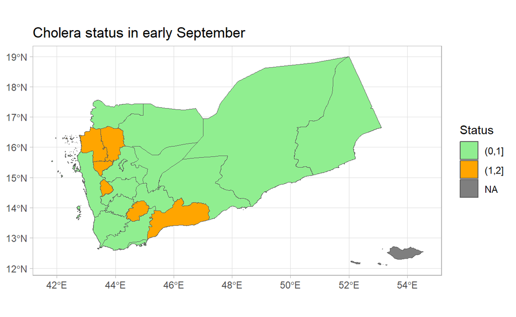

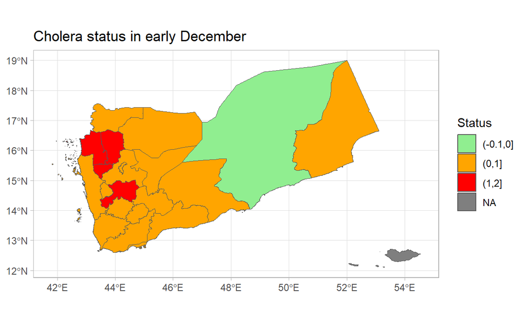

```r
# Fig 1d - Three examples of different epi statuses situation w/colours
tar_read(fig_1d_1) #Epi 2017-23 (early June)
tar_read(fig_1d_2) #Epi 2017-35 (early September)
tar_read(fig_1d_3) #Epi 2017-51 (early December)
```

From the key epidemiological variables, a general 3-coded status can be calculated. The cut-off has been defined within the scope of this work without external validation (e.g., with government-level risk assessment tools). Nevertheless, it uses similar definitions:

- A green area is an area without any new cases in the past four weeks (which is slightly shorter than the WHO standard of 40 days)
- An orange area is an area with an active outbreak where the health system is responding effectively
- A red area is an area where the health system resources are not enough to keep either the CFR under the 1% threshold (representing a situation where sick people access the proper care and the adequate number of cases is intercepted by healthcare staff), or an attack rate over 2 (x1000) signalling a high level of community transmission, or failure of the mitigation measures.

Combined, the status provides a glimpse of the situation in the country. This is a useful target variable to predict, given the direct questions it can answer for managing humanitarian operations.

### Data exploration and visualisation - Correlations

As a preliminary step, correlations with the key epidemiological variables are checked before checking additional modelling strategies.

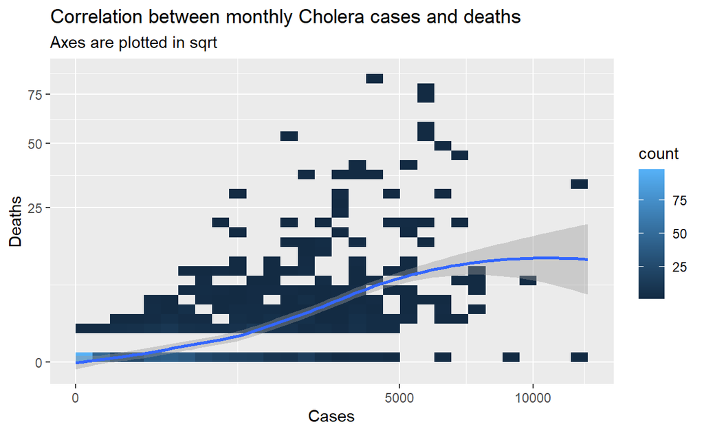

```r
#Fig 2a - correlation between new cases and deaths
tar_read(fig_2_a) +
  labs(x = "Cases", y = "Deaths")
```

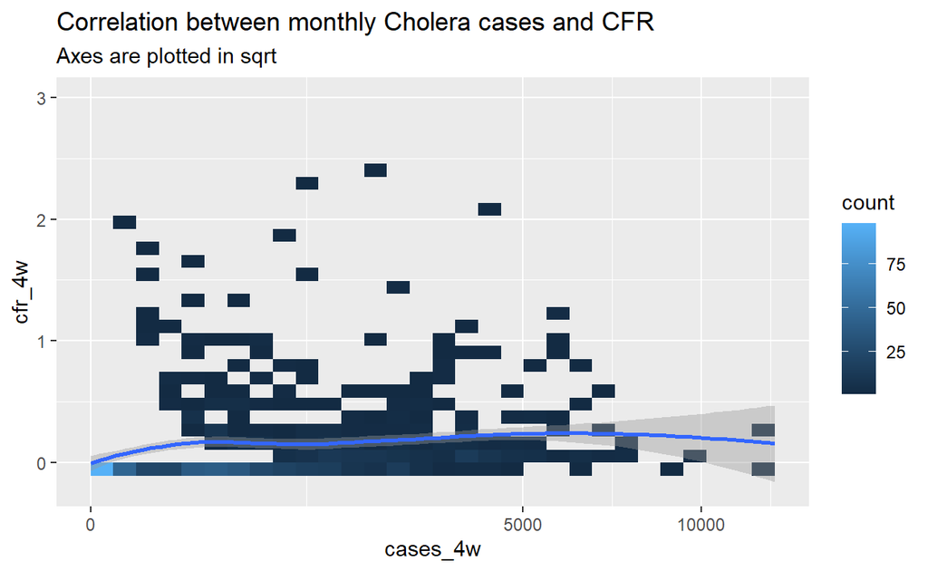

```r
#Fig 2b - correlation between new cases and cfr
tar_read(fig_2_b) +
  ylim(-0.2,3)
```

The same pattern is not so evident for the Case Fatality Rate, even if more cases are associated with a higher CFR in the same period. Even in this case, the preliminary model suggests a different approach incorporating lag considerations of a couple of weeks.

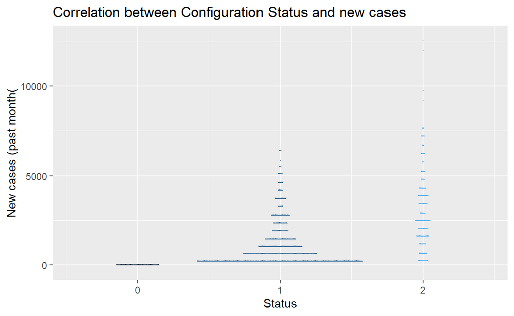

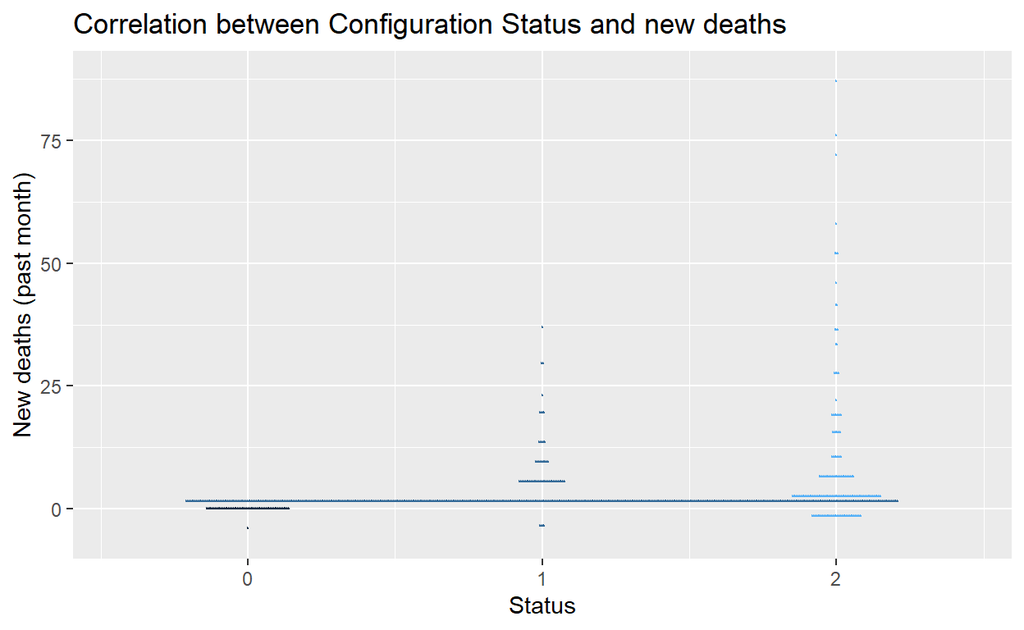

```r
#Fig 2c - correlation between status and 4 epi variables (4 panels)
tar_read(fig_2c_1)
tar_read(fig_2c_2)
```

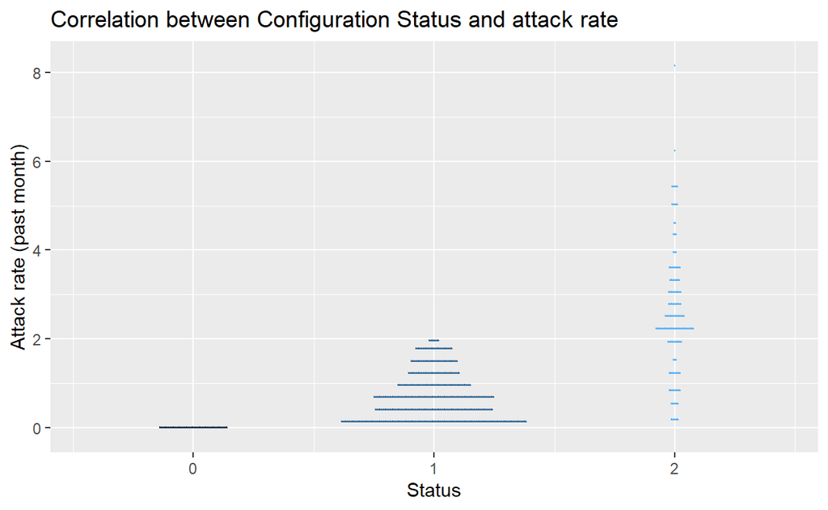

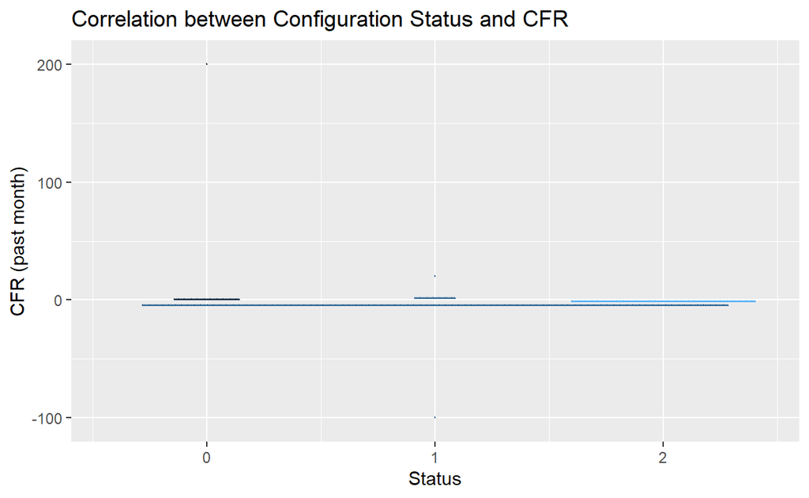

```r
#Fig 2c - correlation between status and 4 epi variables (4 panels)
tar_read(fig_2c_3)
tar_read(fig_2c_4)
```

How the status variable was built forces a certain level of correlation among the variables. This is less evident for the first two variables (cases and deaths) since the Attack rate and CFR are used to determine them.

### Time series

There are several methods to control for long-term and seasonal patterns in time series studies. Given the limited number of years, no seasonality can be modelled. The long-term component is added to the model since the cases’ growth slowly increased. It is expected to be non-linear by applying splines to model smooth temporal trends, initially with 5 degrees of freedom for each year of data.

```r
tar_read(epi_conf)
```

```
            exp(Est.)      2.5%     97.5%
(Intercept) 1.1739742 1.0379980 1.3277631
cases_4w    0.9999892 0.9999695 1.0000089
deaths_4w   1.0035214 1.0004247 1.0066278
cfr_4w      0.9962295 0.9923867 1.0000872
attack_4w   1.2046231 1.1710923 1.2391139
spltime1    0.9717519 0.7513861 1.2567463
spltime2    0.7843001 0.6313142 0.9743590
spltime3    0.8231983 0.6716576 1.0089300
spltime4    0.9065515 0.7528743 1.0915974
spltime5    0.7674057 0.6336032 0.9294641
spltime6    0.7153567 0.5801478 0.8820772
spltime7    0.8730870 0.6592717 1.1562470
spltime8    0.5678887 0.4348246 0.7416729
spltime9    0.5589452 0.4226508 0.7391912
spltime10   0.5921480 0.4767952 0.7354085
```

In the second iteration, the association between the status and the four epidemiological variables (in the previous month) is evaluated, accounting for lagged associations up to four weeks. A bidimensional exposure-lag-response function is defined (cross-basis), with four different models that can be fit from it.

[figure not shown]

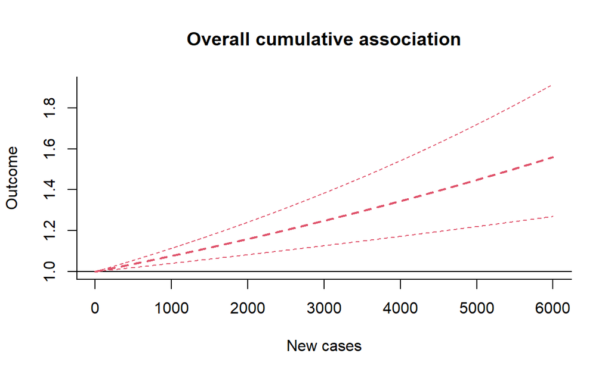

```r
tar_load(ycc_lag)
cb_cases <- dlnm::crossbasis(
  ycc_lag["cases_4w"],
  lag=4,
  argvar=list(fun="lin"),
  arglag=list(fun="integer")
)
spltime <- splines::bs(ycc_lag$date, df=2*3)
mod_cases <- glm(status ~ cb_cases + spltime,
                 family=quasipoisson(),
                 ycc_lag)

cp_cases <- dlnm::crosspred(cb_cases, mod_cases, at=0:6000, by=10)
plot(cp_cases, "slices", var=3000, ci="bars", pch=19, col=2, main="Alternative lag-response functions at Cases = 1200")
plot(cp_cases, "overall", ci="lines", col=2, lty=2,
      main="Overall cumulative association", lwd=2, xlab="New cases")
```

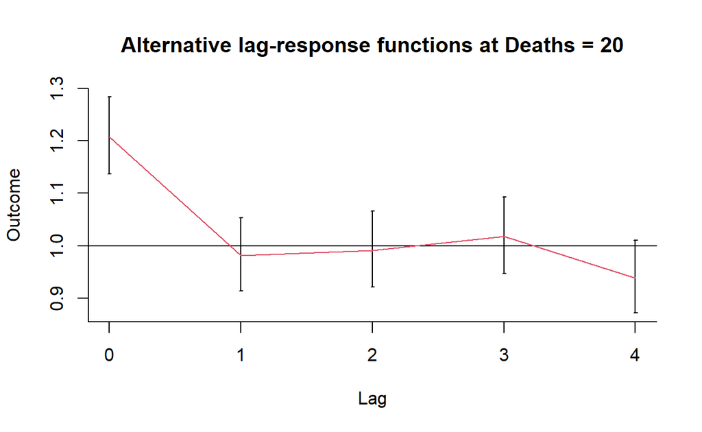

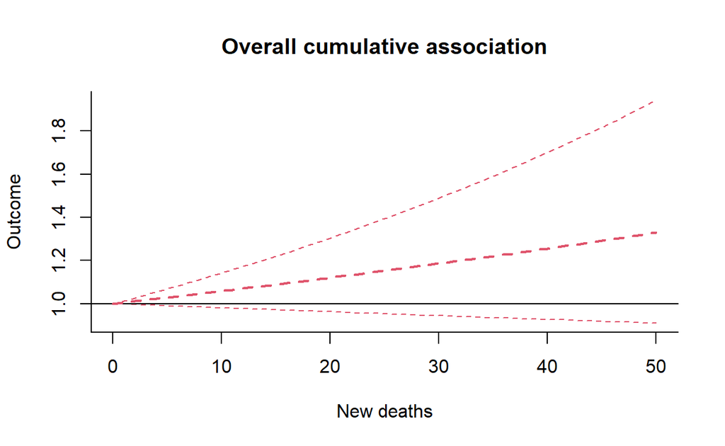

```r
cb_deaths <- dlnm::crossbasis(
  ycc_lag["deaths_4w"],
  lag=4,
  argvar=list(fun="lin"),
  arglag=list(fun="integer")
)
spltime <- splines::bs(ycc_lag$date, df=2*3)
mod_deaths <- glm(status ~ cb_deaths + spltime,
                 family=quasipoisson(),
                 ycc_lag)

cp_deaths <- dlnm::crosspred(cb_deaths, mod_deaths, at=0:50, by=1)
plot(cp_deaths, "slices", var=20, ci="bars", pch=19, col=2, main="Alternative lag-response functions at Deaths = 20")
plot(cp_deaths, "overall", ci="lines", col=2, lty=2,
      main="Overall cumulative association", lwd=2, xlab="New deaths")
```

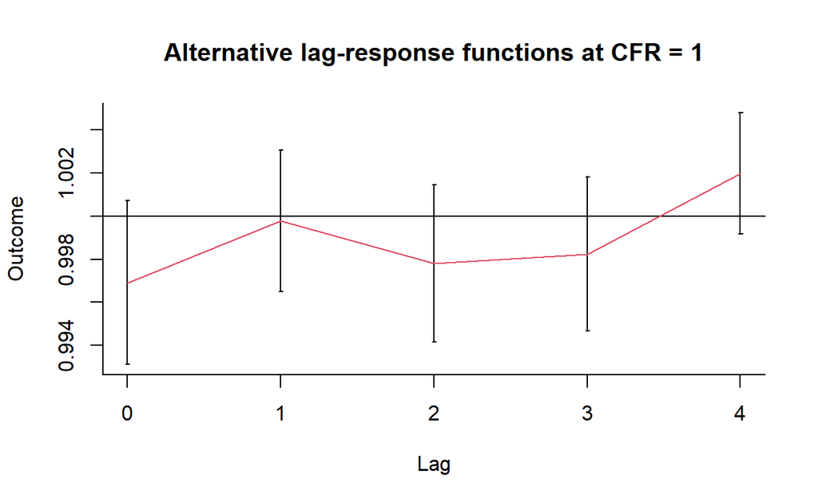

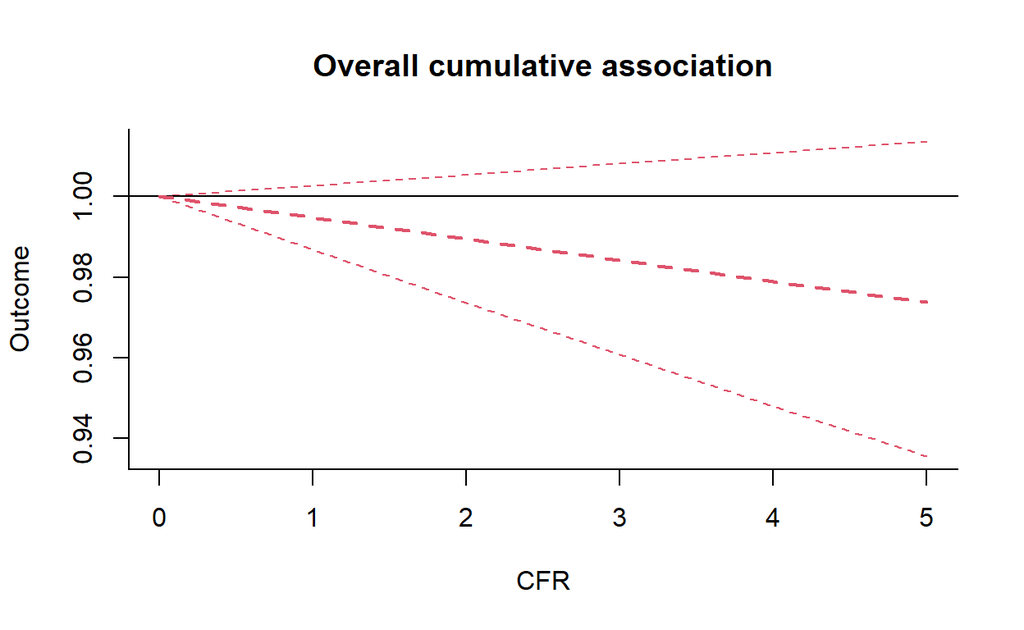

```r
cb_cfr <- dlnm::crossbasis(
  ycc_lag["cfr_4w"],
  lag=4,
  argvar=list(fun="lin"),
  arglag=list(fun="integer")
)
spltime <- splines::bs(ycc_lag$date, df=2*3)
mod_cfr <- glm(status ~ cb_cfr + spltime,
                 family=quasipoisson(),
                 ycc_lag)

cp_cfr <- dlnm::crosspred(cb_cfr, mod_cfr, at=0:5, by=0.1)
plot(cp_cfr, "slices", var=1, ci="bars", pch=19, col=2, main="Alternative lag-response functions at CFR = 1")
plot(cp_cfr, "overall", ci="lines", col=2, lty=2,
      main="Overall cumulative association", lwd=2, xlab="CFR")
```

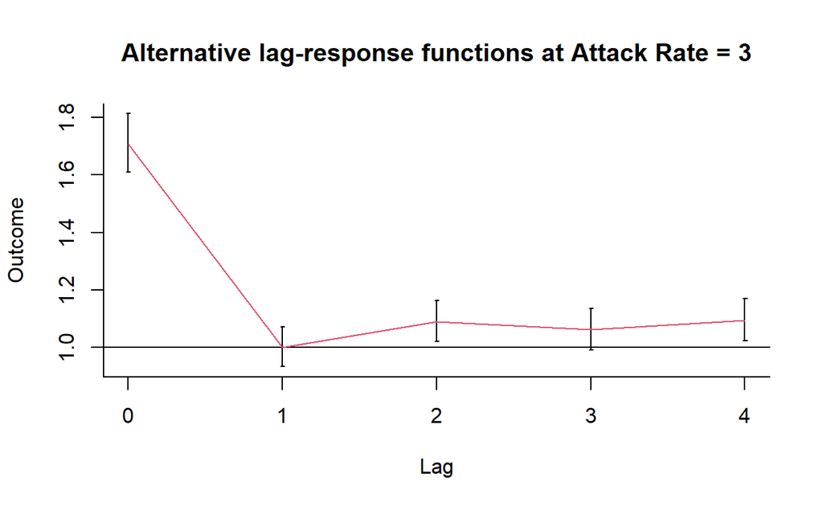

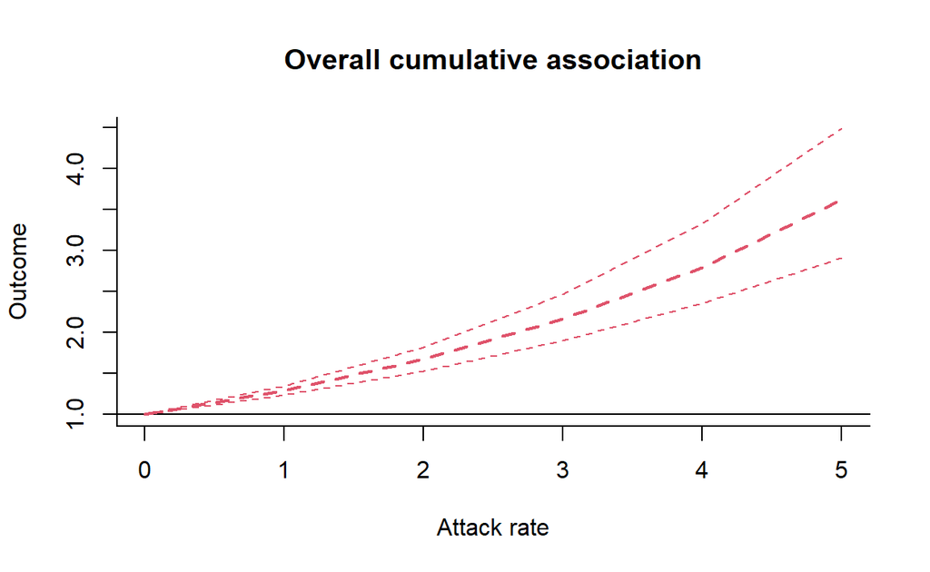

```r
cb_ar <- dlnm::crossbasis(
  ycc_lag["attack_4w"],
  lag=4,
  argvar=list(fun="lin"),
  arglag=list(fun="integer")
)
spltime <- splines::bs(ycc_lag$date, df=2*3)
mod_ar <- glm(status ~ cb_ar + spltime,
                 family=quasipoisson(),
                 ycc_lag)

cp_attack <- dlnm::crosspred(cb_ar, mod_ar, at=0:5, by=0.05)
plot(cp_attack, "slices", var=3, ci="bars", pch=19, col=2, main="Alternative lag-response functions at Attack Rate = 3")
plot(cp_attack, "overall", ci="lines", col=2, lty=2,
      main="Overall cumulative association", lwd=2, xlab="Attack rate")
```

The last iteration is to verify the association at the single governorate level, and a dual-stage approach is used:

- A regression model in which the association of interest is estimated in each location, identical to the first model developed above;
- A meta-analysis to pool the estimates across locations.

This does not consider the effect of geographical proximity, only the temporal association across the estimates.

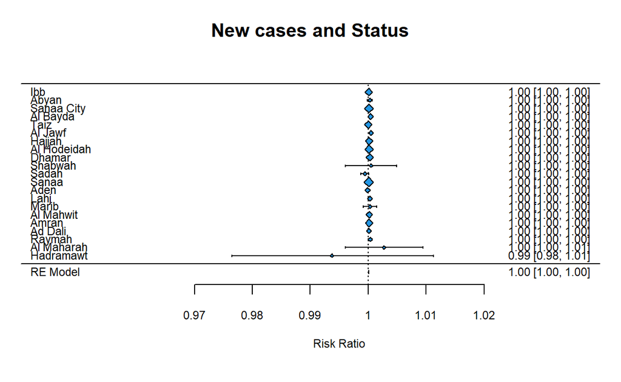

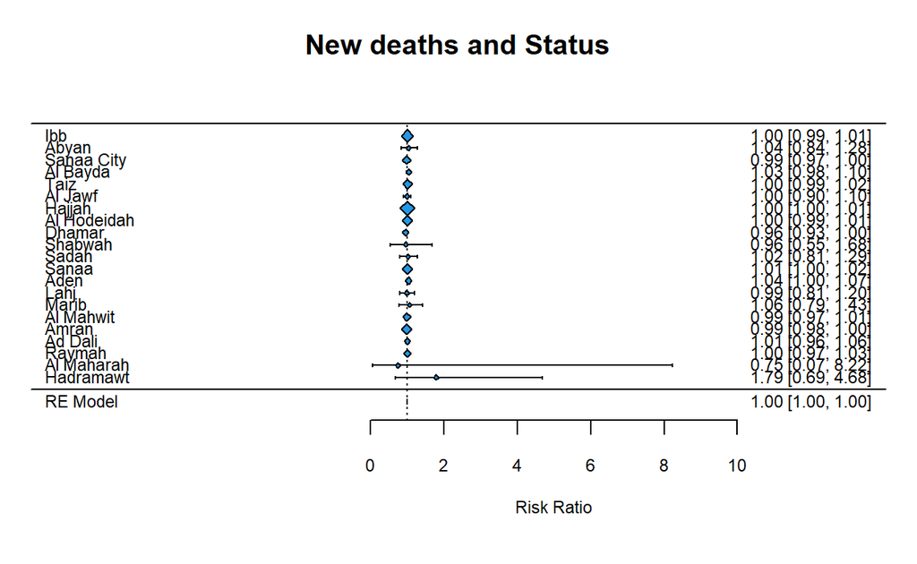

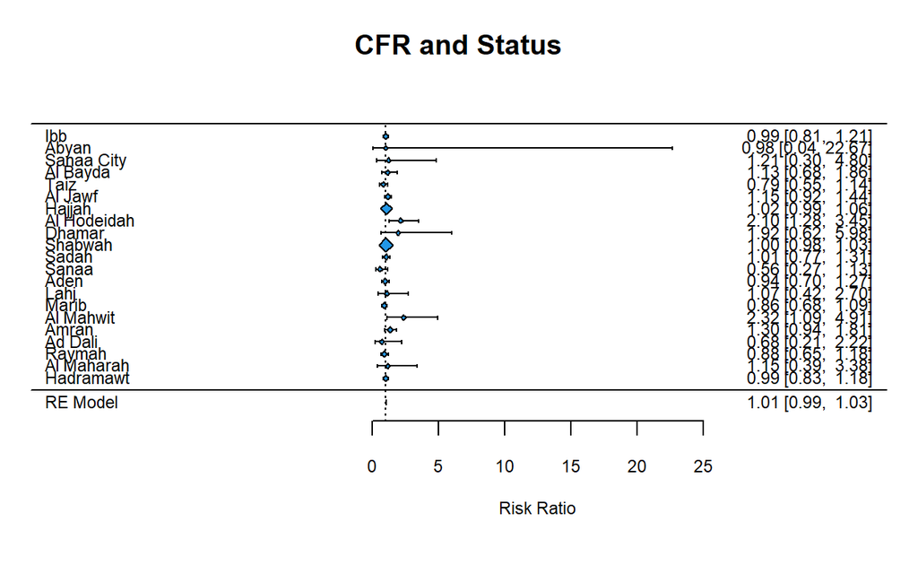

```r
tar_load(log_epi)
regs <- log_epi[["Governorate"]] |> unique()

uni_cases <- metafor::rma(
  yi=log_epi[["Cases"]],
  sei=log_epi[["CasesSE"]],
  slab=regs,
  measure="RR"
  )
metafor::forest(uni_cases, transf=exp, refline=1, pch=23, bg=4, col=2,
  main="New cases and Status")

uni_deaths <- metafor::rma(
  yi=log_epi[["Deaths"]],
  sei=log_epi[["DeathsSE"]],
  slab=regs,
  measure="RR"
  )
metafor::forest(uni_deaths, transf=exp, refline=1, pch=23, bg=4, col=2,
  main="New deaths and Status")

uni_cfr <- metafor::rma(
  yi=log_epi[["CFR"]],
  sei=log_epi[["CFRSE"]],
  slab=regs,
  measure="RR"
  )
metafor::forest(uni_cfr, transf=exp, refline=1, pch=23, bg=4, col=2,
  main="CFR and Status")
```

### Ecological Trends

Modelling ecological trends requires the definition of the proper target variable. In each week, the model will try to predict the status of that district in the following one (so with a one-week lag).

Three models are tested, with different epidemiological variables (either cases or attack rate, as they were the only ones in the previous section to show some cumulative association) and the status of the districts as covariates. A Poisson-gamma model with no spatial consideration is used to provide a reference.

#### Model 0 - no spatial component

The first model is a simple Poisson-gamma model with no spatial consideration. The variables are the expected number of cases and the status in the previous week, which are used to predict the status in the following week.

```r
tar_read(mod0) |> summary()
```

```
Call:
glm(formula = target_status ~ cases_exp + status, family = poisson,
    data = db)

Coefficients:
              Estimate Std. Error z value Pr(>|z|)
(Intercept)  9.101e-02  8.920e-02   1.020  0.30764
cases_exp   -1.868e-04  3.389e-05  -5.513 3.53e-08 ***
status       1.708e-01  6.602e-02   2.587  0.00969 **
---
Signif. codes:  0 '***' 0.001 '**' 0.01 '*' 0.05 '.' 0.1 ' ' 1

(Dispersion parameter for poisson family taken to be 1)

    Null deviance: 218.25  on 712  degrees of freedom
Residual deviance: 176.13  on 710  degrees of freedom
  (36 osservazioni eliminate a causa di valori mancanti)
AIC: 1586.2

Number of Fisher Scoring iterations: 5
```

The results, despite showing a significant association for both variables, are non-indicative by themselves and should be considered a baseline.

#### Model 1 - Cases

The first BYM Model is similar to the former but has additional spatial considerations.

```
model
{
    for (i in 1 : 21)
    {
            target_status[i]  ~ dpois(mu[i])
            log(mu[i]) <- log(cases_exp[i]) + alpha0 + b.ete[i] + b.clu[i] + alpha1*status[i]
            rr[i] <- exp(alpha0+b.ete[i]+b.clu[i])
            b.ete[i]~dnorm(0,tau.ete)
            post[i]<-step(rr[i]-1)
    }

    b.clu[1:21] ~ car.normal(adj[], weights[],num[],tau.clu)

    sd.clu<-sd(b.clu[])
    sd.ete<-sd(b.ete[])

    alpha0  ~ dflat()
    alpha1  ~ dnorm(0, 0.0001)
    tau.ete ~ dgamma(0.5,0.0005)
    sigma.ete <-sqrt(1/tau.ete)
    tau.clu ~ dgamma(0.5,0.0005)
    sigma.clu <-sqrt(1/tau.clu)
}
```

After properly initialising this model, we can provide a summary of the estimated coefficient of status. This shows a tendency towards a negative value of the Status variable, where higher statuses (equal to “worse situation”) are inversely associated with a higher status in any particular region.

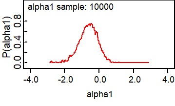

Posterior probability of the Status coefficient (model 1)

```r
tar_read(mod1_alphas)
```

```
# A tibble: 2 × 9
  coefficient   mean    sd MC_error val2.5pc median val97.5pc start
  <chr>        <dbl> <dbl>    <dbl>    <dbl>  <dbl>     <dbl> <dbl>
1 alpha0      -6.73  0.751   0.0182    -8.16 -6.74     -5.22      1
2 alpha1      -0.624 0.579   0.0152    -1.82 -0.599     0.426     1
# ℹ 1 more variable: sample <dbl>
```

On the other hand, the effect of alpha0 appears way greater in size.

[output not shown]

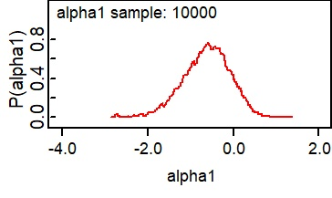

Posterior probability of the Status coefficient (model 2)

```r
tar_read(mod2_alphas)
```

```
# A tibble: 2 × 9
  coefficient   mean    sd MC_error val2.5pc median val97.5pc start
  <chr>        <dbl> <dbl>    <dbl>    <dbl>  <dbl>     <dbl> <dbl>
1 alpha0       7.39  0.732   0.0204     6.00  7.39      8.84      1
2 alpha1      -0.621 0.569   0.0168    -1.81 -0.583     0.380     1
# ℹ 1 more variable: sample <dbl>
```

Alpha 1 is similar to the previous model, even if an opposite effect for alpha0 is shown.

## Conclusions

Cholera spatial dynamics remain elusive as we try to model them. This short report analysed some temporal and spatial patterns (but not the two together) as an exploratory moment before different techniques are tested.

## Acknowledgements

This report (and package) has been prepared as part of the Geostatistics for Health Master’s Degree as the final project work. Data has been acquired through Humanitarian Data Exchange (see relevant section above on data sources), kindly contributed by the United Nations Office for the Coordination of Humanitarian Affairs (UN OCHA) and the World Health Organisation (WHO) together with the Yemen Ministry of Health.

## Author Contributions

AP prepared the first draft of the analysis plan, which FP and DC discussed and improved and provided ongoing feedback on. CL developed the claims analysis template.

“Acute Diarrhea and Cholera Outbreak in Yemen Exacerbated by Decade of Conflict – IOM Warns.” n.d. *International Organization for Migration*. Accessed August 16, 2024. https://www.iom.int/news/acute-diarrhea-and-cholera-outbreak-yemen-exacerbated-decade-conflict-iom-warns.

Alcayna, Tilly. 2023. “Anticipatory Action for Epidemics Briefing.” https://www.anticipation-hub.org/Documents/Briefing_Sheets_and_Fact_Sheets/Anticipatory_Action_for_Epidemics_briefing.pdf.

Ali, Mohammad, Allyson R. Nelson, Anna Lena Lopez, and David A. Sack. 2015. “Updated Global Burden of Cholera in Endemic Countries.” *PLoS Neglected Tropical Diseases* 9 (6): e0003832. https://doi.org/10.1371/journal.pntd.0003832.

“Anticipatory Action – Red Cross Red Crescent Climate Centre.” n.d. Accessed August 16, 2024. https://www.climatecentre.org/priority_areas/fbf-ibf/.

“Anticipatory Action OCHA.” 2024. https://www.unocha.org/anticipatory-action.

“Cadre d’action Anticipatoire I Pilote Au République Démocratique Du Congo: Choléra I Version Préliminaire #4 Du 7 Décembre 2022 OCHA.” 2022. https://www.unocha.org/publications/report/democratic-republic-congo/cadre-daction-anticipatoire-i-pilote-au-republique-democratique-du-congo-cholera-i-version-preliminaire-4-du-7-decembre-2022.

“Cholera.” n.d. Accessed August 16, 2024. https://www.who.int/news-room/fact-sheets/detail/cholera.

“Cholera IFRC.” 2024. https://www.ifrc.org/our-work/health-and-care/community-health/communicable-diseases/cholera.

Dureab, Fekri, Osan Ismail, Olaf Müller, and Albrecht Jahn. 2019. “Cholera Outbreak in Yemen: Timeliness of Reporting and Response in the National Electronic Disease Early Warning System.” *Acta Informatica Medica* 27 (2): 85–88. https://doi.org/10.5455/aim.2019.27.85-88.

“Ending Cholera - A Global Roadmap to 2030 - World ReliefWeb.” 2017. https://reliefweb.int/report/world/ending-cholera-global-roadmap-2030.

“Getting Ahead of Cholera and Putting Cholera Behind.” n.d. *Anticipation Hub*. Accessed August 16, 2024. https://www.anticipation-hub.org/news/getting-ahead-of-cholera-and-putting-cholera-behind.

“Health and Anticipatory Action.” n.d. *Anticipation Hub*. Accessed August 16, 2024. https://www.anticipation-hub.org/learn/emerging-topics/health.

Lunn, David, David Spiegelhalter, Andrew Thomas, and Nicky Best. 2009. “The BUGS Project: Evolution, Critique and Future Directions.” *Statistics in Medicine* 28 (25): 3049–67. https://doi.org/10.1002/sim.3680.

Ng, Qin Xiang, Michelle Lee Zhi Qing De Deyn, Wayren Loke, and Wee Song Yeo. 2020. “Yemen’s Cholera Epidemic Is a One Health Issue.” *Journal of Preventive Medicine and Public Health* 53 (4): 289–92. https://doi.org/10.3961/jpmph.20.154.

“Operational Framework for Anticipatory Action 2021-2025 IFRC.” 2022. https://www.ifrc.org/document/operational-framework-anticipatory-action-2021-2025.

Paz, Shlomit. 2019. “The Cholera Epidemic in Yemen - How Did It Start? The Role of El Niño Conditions Followed by Regional Winds.” *Environmental Research* 176 (September): 108571. https://doi.org/10.1016/j.envres.2019.108571.

“Public Health Emergencies: Preparedness and Response.” n.d.

R Core Team. 2023. *R: A Language and Environment for Statistical Computing*. Vienna, Austria: R Foundation for Statistical Computing. https://www.R-project.org/.

“Risk Assessment WHO.” n.d. Accessed August 24, 2024. https://www.who.int/emergencies/risk-assessments.

“UNICEF Yemen Humanitarian Situation Report No. 1 - January to March 2024 [EN/AR] - Yemen ReliefWeb.” 2024. https://reliefweb.int/report/yemen/unicef-yemen-humanitarian-situation-report-no-1-january-march-2024-enar.

“What Is Anticipatory Action?” n.d. *Anticipation Hub*. Accessed August 16, 2024. https://www.anticipation-hub.org/about/what-is-anticipatory-action.

“World Bank Open Data.” n.d. *World Bank Open Data*. Accessed August 17, 2024. https://data.worldbank.org.

“World Disasters Report 2020 IFRC.” n.d. Accessed August 17, 2024. https://www.ifrc.org/document/world-disasters-report-2020.

“Yemen - Subnational Administrative Boundaries - Humanitarian Data Exchange.” n.d. Accessed August 17, 2024. https://data.humdata.org/dataset/cod-ab-yem.

“Yemen – Cholera Outbreak (DG ECHO, DG ECHO Partners) (ECHO Daily Flash of 4 December 2023) - Yemen ReliefWeb.” 2023. https://reliefweb.int/report/yemen/yemen-cholera-outbreak-dg-echo-dg-echo-partners-echo-daily-flash-4-december-2023.

“Yemen: Cholera Outbreak Epidemiology Update Data - Humanitarian Data Exchange.” n.d. Accessed August 17, 2024. https://data.humdata.org/dataset/yemen-cholera-outbreak-daily-epidemiology-update?